# CSCI E-63C: Week 5 Q&A session

# Questions

- Past homework?
- Past lectures?

# This week homework

Go over preface and questions

# This week quiz

Go over a question of your choice; question 6 resulted in few questions in the past…

# Learning something new every day…

```r
class(iris)
```

```
## [1] "data.frame"
```

```r
dim(iris)
```

```
## [1] 150   5
```

```r
iris[1:3,]
```

```
##   Sepal.Length Sepal.Width Petal.Length Petal.Width Species
## 1          5.1         3.5          1.4         0.2  setosa
## 2          4.9         3.0          1.4         0.2  setosa
## 3          4.7         3.2          1.3         0.2  setosa
```

```r
class(iris[,"Species"])
```

```
## [1] "factor"
```

```r
head(iris[,"Species"])
```

```
## [1] setosa setosa setosa setosa setosa setosa
## Levels: setosa versicolor virginica
```

```r
head(iris$Species)
```

```
## [1] setosa setosa setosa setosa setosa setosa
## Levels: setosa versicolor virginica
```

```r
if ( FALSE ) {
  # this will throw an error:
  head(iris[,"Speciess"])
}
# this will return NULL:
head(iris$Speciess)
```

[output not shown]

```r
# What would this do:
class(iris[1:3,"Speciess"])
```

[output not shown]

```r
iris[1:3,"Speciess"]
```

[output not shown]

# Chapter 6, Exercise 8

*“In this exercise, we will generate simulated data, and will then use this data to perform best subset selection.”*

*“(a) Use the `rnorm()` function to generate a predictor $X$ of length $n = 100$, as well as a noise vector $\epsilon$ of length $n = 100$.”*

```r
x <- rnorm(100)
eps <- 1.0*rnorm(100)
```

*“(b) Generate a response vector $Y$ of length $n = 100$ according to the model $Y = \beta_0 + \beta_1X + \beta_2X^2 + \beta_3X^3 + \epsilon$, where $\beta_0$, $\beta_1$, $\beta_2$, and $\beta_3$ are constants of your choice.”*

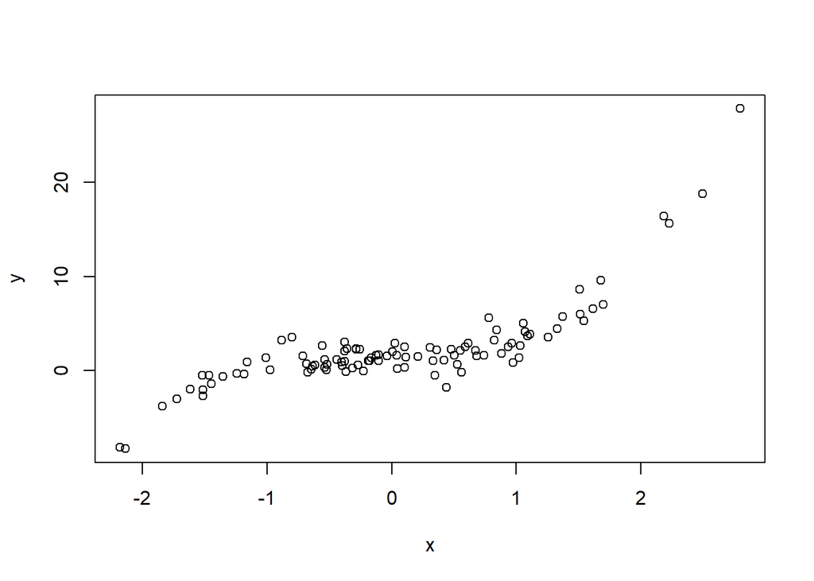

```r
beta <- rexp(4)
y <- beta[1]+beta[2]*x+beta[3]*x^2+beta[4]*x^3+eps
##y <- beta[1]+beta[2]*x^7+eps
plot(x,y)
```

*“(c) Use the regsubsets() function to perform best subset selection in order to choose the best model containing the predictors $X, X^2, \ldots, X^{10}$. What is the best model obtained according to $C_p$, BIC, and adjusted $R^2$? Show some plots to provide evidence for your answer, and report the coefficients of the best model obtained. Note you will need to use the `data.frame()` function to create a single data set containing both $X$ and $Y$.”*

*“(d) Repeat (c), using forward stepwise selection and also using backwards stepwise selection. How does your answer compare to the results in (c)?”*

```r
dfTmp <- data.frame(Y=y,X1=x)
for ( iTmp in 2:10 ) {
  dfTmp[,paste0("X",iTmp)] <- dfTmp[,"X1"]^iTmp
}
head(dfTmp)
```

```
##            Y         X1         X2           X3           X4            X5
## 1 2.27874524 -0.2835219 0.08038465 -0.022790805 0.0064616915 -1.832031e-03
## 2 2.87543879  0.6167423 0.38037111  0.234590970 0.1446821835  8.923163e-02
## 3 4.09423949  1.0722769 1.14977771  1.232880060 1.3219887872  1.417538e+00
## 4 5.27843343  1.5454647 2.38846110  3.691282297 5.7047464465  8.816484e+00
## 5 0.06455018 -0.9769297 0.95439162 -0.932373515 0.9108633712 -8.898495e-01
## 6 0.99463984 -0.1050857 0.01104301 -0.001160463 0.0001219481 -1.281501e-05
##             X6            X7           X8            X9          X10
## 1 5.194208e-04 -1.472672e-04 4.175346e-05 -1.183802e-05 3.356337e-06
## 2 5.503292e-02  3.394113e-02 2.093293e-02  1.291023e-02 7.962283e-03
## 3 1.519993e+00  1.629854e+00 1.747654e+00  1.873969e+00 2.009414e+00
## 4 1.362556e+01  2.105783e+01 3.254413e+01  5.029581e+01 7.773039e+01
## 5 8.693204e-01 -8.492649e-01 8.296721e-01 -8.105313e-01 7.918321e-01
## 6 1.346674e-06 -1.415163e-07 1.487134e-08 -1.562766e-09 1.642244e-10
```

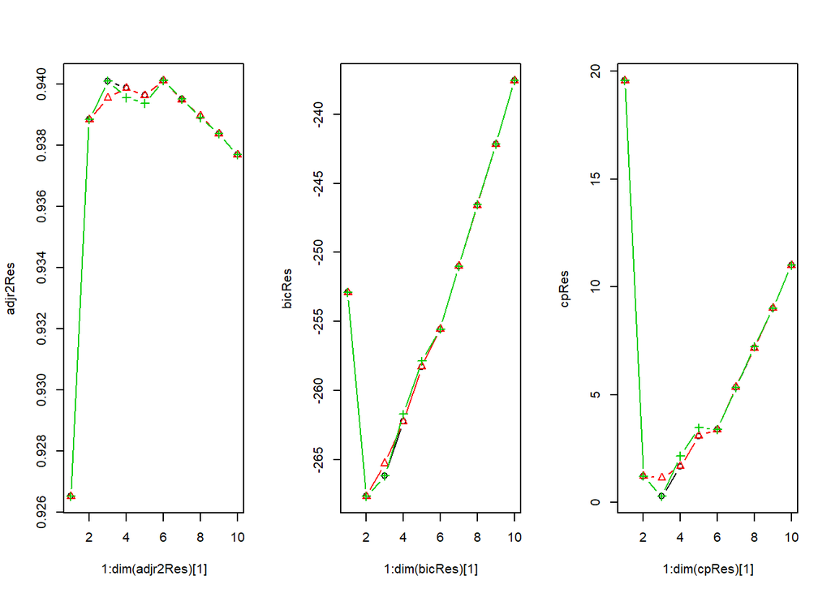

```r
adjr2Res <- NULL
bicRes <- NULL
cpRes <- NULL
for ( jSelect in c("exhaustive","backward", "forward") ) {
  rsRes <- regsubsets(Y~.,dfTmp,nvmax=10,method=jSelect)
  summary(rsRes)
  adjr2Res <- cbind(adjr2Res,summary(rsRes)$adjr2)
  bicRes <- cbind(bicRes,summary(rsRes)$bic)
  cpRes <- cbind(cpRes,summary(rsRes)$cp)
}
old.par<-par(mfrow=c(1,3))
matplot(1:dim(adjr2Res)[1],adjr2Res,type="b",pch=1:ncol(adjr2Res),lty=1)
matplot(1:dim(bicRes)[1],bicRes,type="b",pch=1:ncol(bicRes),lty=1)
matplot(1:dim(cpRes)[1],cpRes,type="b",pch=1:ncol(bicRes),lty=1)
```

```r
par(old.par)
```

*“(e) Now fit a lasso model to the simulated data, again using $X, X_2, \ldots, X^{10}$ as predictors. Use cross-validation to select the optimal value of $\lambda$. Create plots of the cross-validation error as a function of $\lambda$. Report the resulting coefficient estimates, and discuss the results obtained.”*

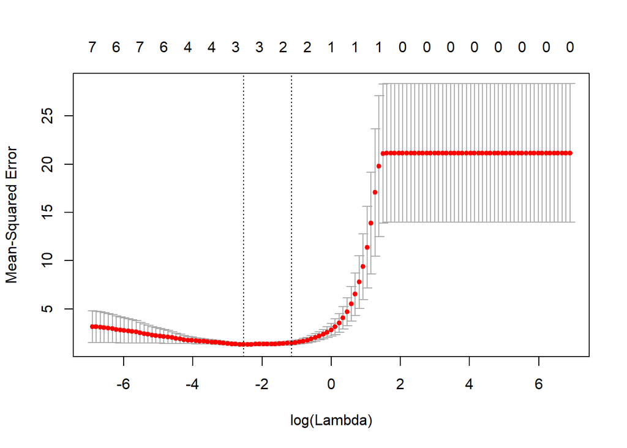

```r
lassoRes <- glmnet(model.matrix(Y~.,dfTmp)[,-1],dfTmp$Y,alpha=1)
lassoResCV <- cv.glmnet(model.matrix(Y~.,dfTmp)[,-1],dfTmp$Y,alpha=1,lambda=10^((-60:60)/20))
plot(lassoResCV)
```

```r
predict(lassoResCV,type="coefficients",s=lassoResCV$lambda.1se)
```

```
## 11 x 1 sparse Matrix of class "dgCMatrix"
##                     1
## (Intercept) 1.5648851
## X1          .
## X2          0.2348454
## X3          1.0292418
## X4          .
## X5          .
## X6          .
## X7          .
## X8          .
## X9          .
## X10         .
```

```r
beta
```

```
## [1] 1.4663579 0.2557027 0.4355124 1.0001358
```

```r
predict(lassoResCV,type="coefficients",s=lassoResCV$lambda.min)
```

```
## 11 x 1 sparse Matrix of class "dgCMatrix"
##                     1
## (Intercept) 1.4143335
## X1          0.1169525
## X2          0.3633866
## X3          1.0456116
## X4          .
## X5          .
## X6          .
## X7          .
## X8          .
## X9          .
## X10         .
```

*“(f) Now generate a response vector Y according to the model $Y = \beta_0 + \beta_7X^7 + \epsilon$, and perform best subset selection and the lasso. Discuss the results obtained.”*

See commented out code above

# Chapter 6, Exercise 9

*“In this exercise, we will predict the number of applications received using the other variables in the `College` data set.”*

```r
head(College)
```

```
##                              Private Apps Accept Enroll Top10perc
## Abilene Christian University     Yes 1660   1232    721        23
## Adelphi University               Yes 2186   1924    512        16
## Adrian College                   Yes 1428   1097    336        22
## Agnes Scott College              Yes  417    349    137        60
## Alaska Pacific University        Yes  193    146     55        16
## Albertson College                Yes  587    479    158        38
##                              Top25perc F.Undergrad P.Undergrad Outstate
## Abilene Christian University        52        2885         537     7440
## Adelphi University                  29        2683        1227    12280
## Adrian College                      50        1036          99    11250
## Agnes Scott College                 89         510          63    12960
## Alaska Pacific University           44         249         869     7560
## Albertson College                   62         678          41    13500
##                              Room.Board Books Personal PhD Terminal
## Abilene Christian University       3300   450     2200  70       78
## Adelphi University                 6450   750     1500  29       30
## Adrian College                     3750   400     1165  53       66
## Agnes Scott College                5450   450      875  92       97
## Alaska Pacific University          4120   800     1500  76       72
## Albertson College                  3335   500      675  67       73
##                              S.F.Ratio perc.alumni Expend Grad.Rate
## Abilene Christian University      18.1          12   7041        60
## Adelphi University                12.2          16  10527        56
## Adrian College                    12.9          30   8735        54
## Agnes Scott College                7.7          37  19016        59
## Alaska Pacific University         11.9           2  10922        15
## Albertson College                  9.4          11   9727        55
```

```r
dim(College)
```

```
## [1] 777  18
```

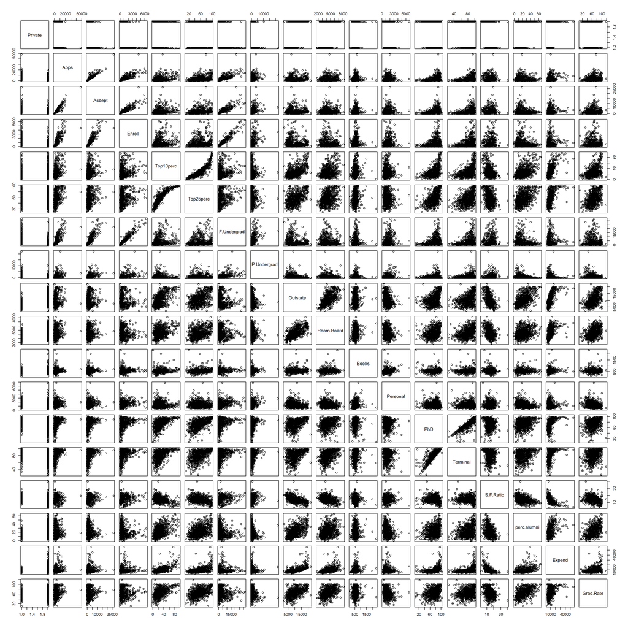

```r
pairs(College)
```

*“(a) Split the data set into a training set and a test set.”*

```r
idxTrain <- sample(nrow(College),nrow(College)/2)
```

*“(b) Fit a linear model using least squares on the training set, and report the test error obtained.”*

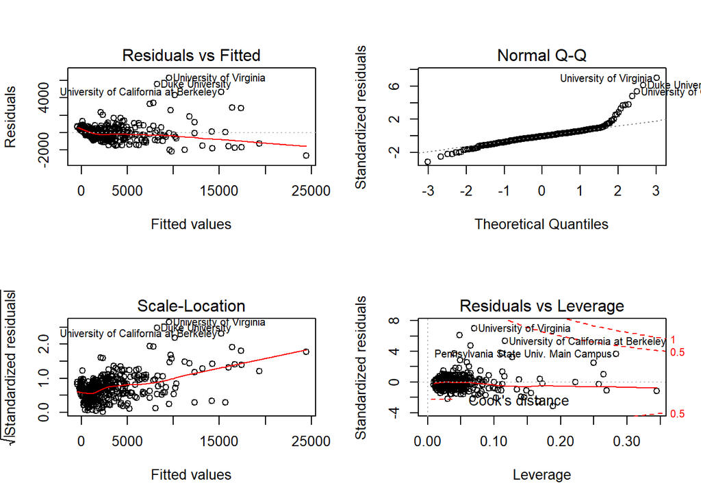

```r
lmTmp <- lm(Apps~.,College[idxTrain,])
old.par <- par(mfrow=c(2,2))
plot(lmTmp)
```

```r
par(old.par)
summary(lmTmp)
```

```
##
## Call:
## lm(formula = Apps ~ ., data = College[idxTrain, ])
##
## Residuals:
##     Min      1Q  Median      3Q     Max
## -2655.1  -439.7   -57.5   327.9  6313.1
##
## Coefficients:
##               Estimate Std. Error t value Pr(>|t|)
## (Intercept)  1.179e+01  5.174e+02   0.023 0.981833
## PrivateYes  -7.858e+02  1.829e+02  -4.297 2.21e-05 ***
## Accept       1.285e+00  6.028e-02  21.318  < 2e-16 ***
## Enroll      -6.584e-01  2.282e-01  -2.885 0.004146 **
## Top10perc    4.644e+01  6.610e+00   7.025 1.03e-11 ***
## Top25perc   -1.129e+01  5.423e+00  -2.082 0.038046 *
## F.Undergrad  1.442e-01  3.805e-02   3.790 0.000176 ***
## P.Undergrad -9.922e-02  5.555e-02  -1.786 0.074865 .
## Outstate    -3.259e-02  2.418e-02  -1.348 0.178598
## Room.Board   1.519e-01  6.078e-02   2.500 0.012851 *
## Books        1.267e-02  3.285e-01   0.039 0.969266
## Personal    -5.207e-03  8.443e-02  -0.062 0.950853
## PhD         -1.362e+01  6.429e+00  -2.119 0.034743 *
## Terminal    -9.605e-01  6.633e+00  -0.145 0.884939
## S.F.Ratio    1.035e+01  1.628e+01   0.636 0.525274
## perc.alumni -8.613e+00  5.183e+00  -1.662 0.097424 .
## Expend       6.025e-02  1.405e-02   4.288 2.31e-05 ***
## Grad.Rate    8.387e+00  3.679e+00   2.280 0.023181 *
## ---
## Signif. codes:  0 '***' 0.001 '**' 0.01 '*' 0.05 '.' 0.1 ' ' 1
##
## Residual standard error: 934.7 on 370 degrees of freedom
## Multiple R-squared:  0.9376, Adjusted R-squared:  0.9347
## F-statistic: 326.8 on 17 and 370 DF,  p-value: < 2.2e-16
```

```r
mean((College[-idxTrain,]$Apps-predict(lmTmp,newdata=College[-idxTrain,]))^2)
```

```
## [1] 1576968
```

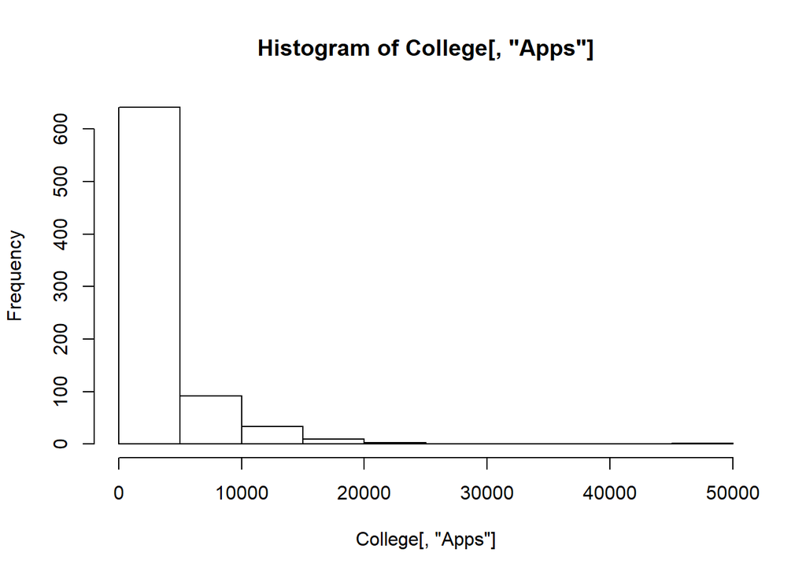

```r
hist(College[,'Apps'])
```

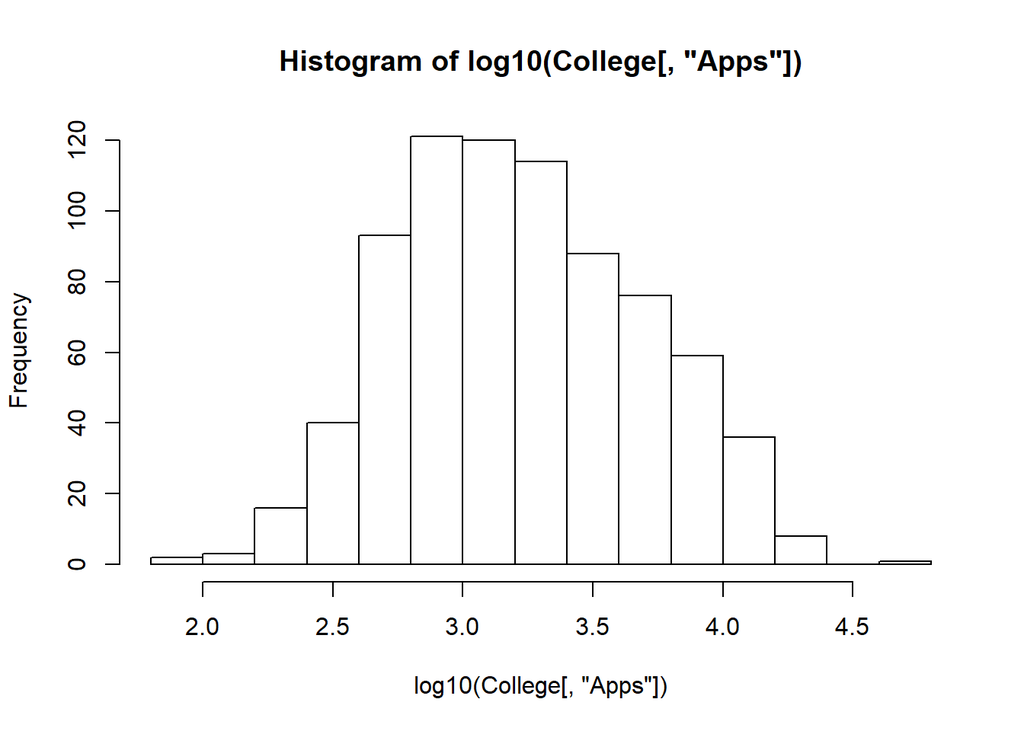

```r
hist(log10(College[,'Apps']))
```

More work to be done here - Apps probably has to be log-transformed, to be less skewed, what about other variables? Accept seems to be very highly correlated with Apps, but this is just direct consequence of the fact that the more applications are submitted, the more are accepted, college size, etc. Do we need to adjust for college size so that it is not the main property we are discovering?

*“(c) Fit a ridge regression model on the training set, with $\lambda$ chosen by cross-validation. Report the test error obtained.”*

```r
mmTmp <- model.matrix(Apps~.,College)
head(mmTmp)
```

```
##                              (Intercept) PrivateYes Accept Enroll
## Abilene Christian University           1          1   1232    721
## Adelphi University                     1          1   1924    512
## Adrian College                         1          1   1097    336
## Agnes Scott College                    1          1    349    137
## Alaska Pacific University              1          1    146     55
## Albertson College                      1          1    479    158
##                              Top10perc Top25perc F.Undergrad P.Undergrad
## Abilene Christian University        23        52        2885         537
## Adelphi University                  16        29        2683        1227
## Adrian College                      22        50        1036          99
## Agnes Scott College                 60        89         510          63
## Alaska Pacific University           16        44         249         869
## Albertson College                   38        62         678          41
##                              Outstate Room.Board Books Personal PhD
## Abilene Christian University     7440       3300   450     2200  70
## Adelphi University              12280       6450   750     1500  29
## Adrian College                  11250       3750   400     1165  53
## Agnes Scott College             12960       5450   450      875  92
## Alaska Pacific University        7560       4120   800     1500  76
## Albertson College               13500       3335   500      675  67
##                              Terminal S.F.Ratio perc.alumni Expend
## Abilene Christian University       78      18.1          12   7041
## Adelphi University                 30      12.2          16  10527
## Adrian College                     66      12.9          30   8735
## Agnes Scott College                97       7.7          37  19016
## Alaska Pacific University          72      11.9           2  10922
## Albertson College                  73       9.4          11   9727
##                              Grad.Rate
## Abilene Christian University        60
## Adelphi University                  56
## Adrian College                      54
## Agnes Scott College                 59
## Alaska Pacific University           15
## Albertson College                   55
```

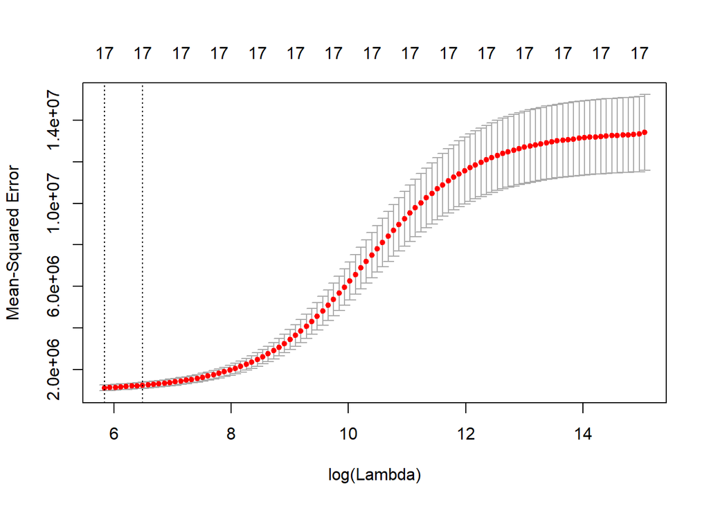

```r
# get rid of intercept:
glmnetRidgeResCV <- cv.glmnet(mmTmp[idxTrain,-1], College[idxTrain,"Apps"], alpha=0)
plot(glmnetRidgeResCV)
```

```r
glmnetRidgeResCV$lambda.1se
```

```
## [1] 660.2175
```

```r
mean((College[-idxTrain,]$Apps-predict(glmnetRidgeResCV,mmTmp[-idxTrain,-1]))^2)
```

```
## [1] 2626968
```

*“(d) Fit a lasso model on the training set, with $\lambda$ chosen by crossvalidation. Report the test error obtained, along with the number of non-zero coefficient estimates.”*

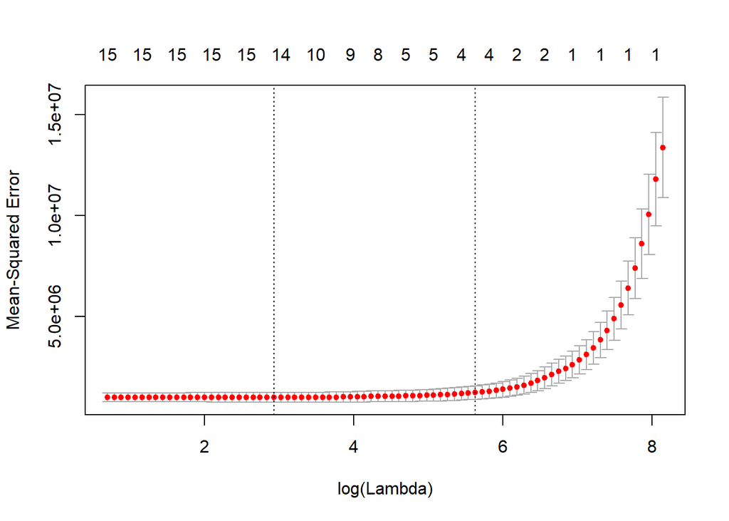

```r
# get rid of intercept:
glmnetLassoResCV <- cv.glmnet(mmTmp[idxTrain,-1], College[idxTrain,"Apps"], alpha=1)
plot(glmnetLassoResCV)
```

```r
glmnetLassoResCV$lambda.1se
```

```
## [1] 279.222
```

```r
mean((College[-idxTrain,]$Apps-predict(glmnetLassoResCV,mmTmp[-idxTrain,-1]))^2)
```

```
## [1] 1892265
```

*“(e) Fit a PCR model on the training set, with M chosen by crossvalidation. Report the test error obtained, along with the value of M selected by cross-validation.”*

*“(f) Fit a PLS model on the training set, with M chosen by crossvalidation. Report the test error obtained, along with the value of M selected by cross-validation.”*

*“(g) Comment on the results obtained. How accurately can we predict the number of college applications received? Is there much difference among the test errors resulting from these five approaches?”*

# Chapter 6, Exercise 10

*“We have seen that as the number of features used in a model increases, the training error will necessarily decrease, but the test error may not. We will now explore this in a simulated data set.”*

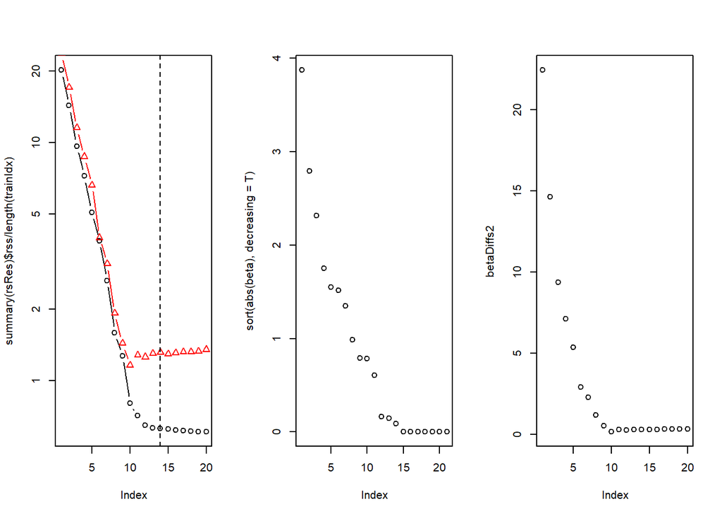

```r
predict.regsubsets <- function(object, newdata, id, ...){
  form=as.formula(object$call[[2]])
  mat=model.matrix(form,newdata)
  coefi=coef(object,id=id)
  xvars=names(coefi)
  mat[,xvars ]%*%coefi
}
###for ( iSim in 1:20 ) {
x <- matrix(rnorm(20*1000),ncol=20)
colnames(x) <- paste0("X",1:ncol(x))
beta <- rexp(21) # plus one for intercept
beta[-sample(length(beta),length(beta),replace=T)] <- 0
y <- cbind(rep(1,nrow(x)),x) %*% beta + rnorm(dim(x)[1])
dfTmp <- data.frame(Y=y,x)
trainIdx <- sample(dim(x)[1],100)
rsRes <- regsubsets(Y~.,dfTmp[trainIdx,],nvmax=20)
testErr <- numeric()
betaDiffs2 <- numeric()
for ( iTmp in 1:20 ) {
  testErr[iTmp] <- mean((dfTmp[-trainIdx,"Y"] - predict(rsRes,dfTmp[-trainIdx,],id=iTmp))^2)
  betaR <- numeric(length(beta))
  names(betaR) <- c("(Intercept)",paste0("X",1:(length(beta)-1)))
  betaR[names(coef(rsRes,id=iTmp))] <- coef(rsRes,id=iTmp)
  betaDiffs2[iTmp] <- sum((beta-betaR)^2)
}
old.par <- par(mfrow=c(1,3))
plot(summary(rsRes)$rss/length(trainIdx),log="y",type="b")
points(testErr,col="red",pch=2,type="b")
abline(v=sum(beta!=0),lty=2)
plot(sort(abs(beta),decreasing=T))
#plot(beta,betaR)
plot(betaDiffs2)
```

```r
par(old.par)
###}
```

# Chapter 5, Exercise 8

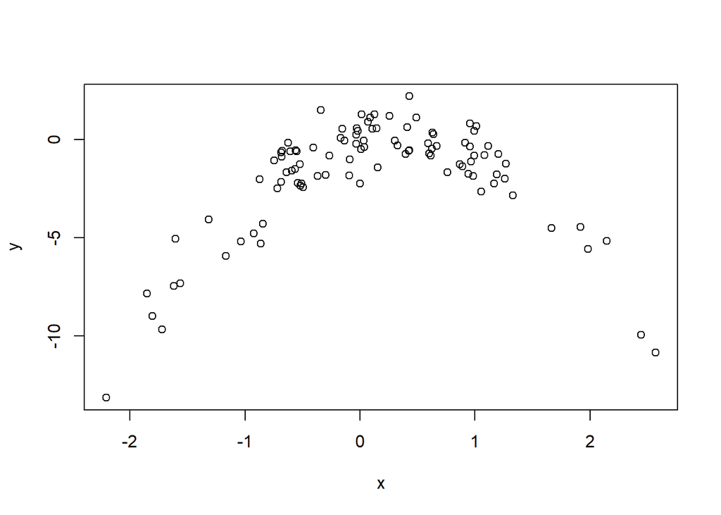

```r
#set.seed (1)
y=rnorm (100)
x=rnorm (100)
y=x-2*x^2+rnorm(100)
plot(x,y)
```

```r
dfTmp <- data.frame(Y=y,X1=x)
for ( iTmp in 2:4 ) {
  dfTmp[,paste0("X",iTmp)] <- dfTmp[,"X1"]^iTmp
}
for ( iTmp in 2:5 ) {
  tmpDiffs <- NULL
  for ( jTmp in 1:nrow(dfTmp) ) {
    lmTmp <- lm(Y~.,dfTmp[-jTmp,1:iTmp])
    tmpDiffs <- c(tmpDiffs,dfTmp[jTmp,'Y']-predict(lmTmp,newdata=dfTmp[jTmp,]))
  }
  cat(iTmp-1,mean(tmpDiffs^2),sd(tmpDiffs^2),fill=T)
  #print(summary(lm(Y~.,dfTmp[,1:iTmp])))
}
```

```
## 1 8.514757 21.03793
## 2 1.113823 1.387965
## 3 1.132235 1.386562
## 4 1.167627 1.411915
```